# Overview

Dataset info

| Number of variables | 131 |
| --- | --- |
| Number of observations | 313864 |
| Total Missing (%) | 0.0% |
| Total size in memory | 313.7 MiB |
| Average record size in memory | 1.0 KiB |

Variables types

| Numeric | 13 |
| --- | --- |
| Categorical | 116 |
| Date | 0 |
| Text (Unique) | 0 |
| Rejected | 2 |

Warnings

- `cat109` has a high cardinality: 85 distinct values Warning
- `cat110` has a high cardinality: 134 distinct values Warning
- `cat112` has a high cardinality: 51 distinct values Warning
- `cat113` has a high cardinality: 63 distinct values Warning
- `cat116` has a high cardinality: 349 distinct values Warning
- `cont12` is highly correlated with `cont11` (ρ = 0.99439) Rejected
- `cont9` is highly correlated with `cont1` (ρ = 0.93067) Rejected

# Variables

cat1  
Categorical

| Distinct count | 2 |
| --- | --- |
| Unique (%) | 0.0% |
| Missing (%) | 0.0% |
| Missing (n) | 0 |

| A | 235646 |
| --- | --- |
| B | 78218 |

Toggle details

| Value | Count | Frequency (%) |  |
| --- | --- | --- | --- |
| A | 235646 | 75.1% |  |
| B | 78218 | 24.9% |  |

cat10  
Categorical

| Distinct count | 2 |
| --- | --- |
| Unique (%) | 0.0% |
| Missing (%) | 0.0% |
| Missing (n) | 0 |

| A | 267157 |
| --- | --- |
| B | 46707 |

Toggle details

| Value | Count | Frequency (%) |  |
| --- | --- | --- | --- |
| A | 267157 | 85.1% |  |
| B | 46707 | 14.9% |  |

cat100  
Categorical

| Distinct count | 15 |
| --- | --- |
| Unique (%) | 0.0% |
| Missing (%) | 0.0% |
| Missing (n) | 0 |

| F | 71817 |
| --- | --- |
| I | 66619 |
| L | 33238 |
| Other values (12) | 142190 |

Toggle details

| Value | Count | Frequency (%) |  |
| --- | --- | --- | --- |
| F | 71817 | 22.9% |  |
| I | 66619 | 21.2% |  |
| L | 33238 | 10.6% |  |
| K | 22852 | 7.3% |  |
| G | 21574 | 6.9% |  |
| J | 19996 | 6.4% |  |
| H | 17797 | 5.7% |  |
| A | 15710 | 5.0% |  |
| N | 12703 | 4.0% |  |
| B | 10954 | 3.5% |  |
| Other values (5) | 20604 | 6.6% |  |

cat101  
Categorical

| Distinct count | 19 |
| --- | --- |
| Unique (%) | 0.0% |
| Missing (%) | 0.0% |
| Missing (n) | 0 |

| A | 177924 |
| --- | --- |
| D | 28819 |
| C | 28215 |
| Other values (16) | 78906 |

Toggle details

| Value | Count | Frequency (%) |  |
| --- | --- | --- | --- |
| A | 177924 | 56.7% |  |
| D | 28819 | 9.2% |  |
| C | 28215 | 9.0% |  |
| G | 18183 | 5.8% |  |
| F | 17021 | 5.4% |  |
| J | 12092 | 3.9% |  |
| I | 11080 | 3.5% |  |
| M | 6084 | 1.9% |  |
| L | 5233 | 1.7% |  |
| Q | 4543 | 1.4% |  |
| Other values (9) | 4670 | 1.5% |  |

cat102  
Categorical

| Distinct count | 9 |
| --- | --- |
| Unique (%) | 0.0% |
| Missing (%) | 0.0% |
| Missing (n) | 0 |

| A | 295386 |
| --- | --- |
| B | 8660 |
| C | 8234 |
| Other values (6) | 1584 |

Toggle details

| Value | Count | Frequency (%) |  |
| --- | --- | --- | --- |
| A | 295386 | 94.1% |  |
| B | 8660 | 2.8% |  |
| C | 8234 | 2.6% |  |
| E | 792 | 0.3% |  |
| D | 740 | 0.2% |  |
| G | 31 | 0.0% |  |
| F | 19 | 0.0% |  |
| H | 1 | 0.0% |  |
| J | 1 | 0.0% |  |

cat103  
Categorical

| Distinct count | 14 |
| --- | --- |
| Unique (%) | 0.0% |
| Missing (%) | 0.0% |
| Missing (n) | 0 |

| A | 206019 |
| --- | --- |
| B | 55494 |
| C | 27792 |
| Other values (11) | 24559 |

Toggle details

| Value | Count | Frequency (%) |  |
| --- | --- | --- | --- |
| A | 206019 | 65.6% |  |
| B | 55494 | 17.7% |  |
| C | 27792 | 8.9% |  |
| D | 12986 | 4.1% |  |
| E | 7535 | 2.4% |  |
| F | 2506 | 0.8% |  |
| G | 904 | 0.3% |  |
| H | 330 | 0.1% |  |
| I | 167 | 0.1% |  |
| J | 78 | 0.0% |  |
| Other values (4) | 53 | 0.0% |  |

cat104  
Categorical

| Distinct count | 17 |
| --- | --- |
| Unique (%) | 0.0% |
| Missing (%) | 0.0% |
| Missing (n) | 0 |

| E | 71557 |
| --- | --- |
| G | 67626 |
| D | 45861 |
| Other values (14) | 128820 |

Toggle details

| Value | Count | Frequency (%) |  |
| --- | --- | --- | --- |
| E | 71557 | 22.8% |  |
| G | 67626 | 21.5% |  |
| D | 45861 | 14.6% |  |
| F | 32069 | 10.2% |  |
| H | 28462 | 9.1% |  |
| K | 24231 | 7.7% |  |
| I | 18346 | 5.8% |  |
| C | 11581 | 3.7% |  |
| L | 5763 | 1.8% |  |
| J | 5225 | 1.7% |  |
| Other values (7) | 3143 | 1.0% |  |

cat105  
Categorical

| Distinct count | 20 |
| --- | --- |
| Unique (%) | 0.0% |
| Missing (%) | 0.0% |
| Missing (n) | 0 |

| E | 127477 |
| --- | --- |
| F | 104812 |
| G | 34295 |
| Other values (17) | 47280 |

Toggle details

| Value | Count | Frequency (%) |  |
| --- | --- | --- | --- |
| E | 127477 | 40.6% |  |
| F | 104812 | 33.4% |  |
| G | 34295 | 10.9% |  |
| D | 20345 | 6.5% |  |
| H | 18763 | 6.0% |  |
| I | 4867 | 1.6% |  |
| J | 1193 | 0.4% |  |
| K | 842 | 0.3% |  |
| C | 449 | 0.1% |  |
| M | 290 | 0.1% |  |
| Other values (10) | 531 | 0.2% |  |

cat106  
Categorical

| Distinct count | 18 |
| --- | --- |
| Unique (%) | 0.0% |
| Missing (%) | 0.0% |
| Missing (n) | 0 |

| G | 78180 |
| --- | --- |
| H | 62597 |
| F | 60520 |
| Other values (15) | 112567 |

Toggle details

| Value | Count | Frequency (%) |  |
| --- | --- | --- | --- |
| G | 78180 | 24.9% |  |
| H | 62597 | 19.9% |  |
| F | 60520 | 19.3% |  |
| I | 35874 | 11.4% |  |
| J | 30373 | 9.7% |  |
| E | 21871 | 7.0% |  |
| K | 13535 | 4.3% |  |
| L | 4872 | 1.6% |  |
| D | 3202 | 1.0% |  |
| M | 1971 | 0.6% |  |
| Other values (8) | 869 | 0.3% |  |

cat107  
Categorical

| Distinct count | 20 |
| --- | --- |
| Unique (%) | 0.0% |
| Missing (%) | 0.0% |
| Missing (n) | 0 |

| F | 78863 |
| --- | --- |
| G | 47225 |
| H | 39144 |
| Other values (17) | 148632 |

Toggle details

| Value | Count | Frequency (%) |  |
| --- | --- | --- | --- |
| F | 78863 | 25.1% |  |
| G | 47225 | 15.0% |  |
| H | 39144 | 12.5% |  |
| J | 37430 | 11.9% |  |
| K | 33908 | 10.8% |  |
| I | 33409 | 10.6% |  |
| E | 20691 | 6.6% |  |
| L | 11849 | 3.8% |  |
| D | 5388 | 1.7% |  |
| M | 3456 | 1.1% |  |
| Other values (10) | 2501 | 0.8% |  |

cat108  
Categorical

| Distinct count | 11 |
| --- | --- |
| Unique (%) | 0.0% |
| Missing (%) | 0.0% |
| Missing (n) | 0 |

| B | 108731 |
| --- | --- |
| K | 71158 |
| G | 35899 |
| Other values (8) | 98076 |

Toggle details

| Value | Count | Frequency (%) |  |
| --- | --- | --- | --- |
| B | 108731 | 34.6% |  |
| K | 71158 | 22.7% |  |
| G | 35899 | 11.4% |  |
| D | 31948 | 10.2% |  |
| F | 16971 | 5.4% |  |
| A | 15417 | 4.9% |  |
| E | 13260 | 4.2% |  |
| I | 12070 | 3.8% |  |
| H | 7180 | 2.3% |  |
| C | 884 | 0.3% |  |

cat109  
Categorical

| Distinct count | 85 |
| --- | --- |
| Unique (%) | 0.0% |
| Missing (%) | 0.0% |
| Missing (n) | 0 |

| BI | 255052 |
| --- | --- |
| AB | 36289 |
| BU | 5316 |
| Other values (82) | 17207 |

Toggle details

| Value | Count | Frequency (%) |  |
| --- | --- | --- | --- |
| BI | 255052 | 81.3% |  |
| AB | 36289 | 11.6% |  |
| BU | 5316 | 1.7% |  |
| K | 4956 | 1.6% |  |
| G | 2264 | 0.7% |  |
| BQ | 1788 | 0.6% |  |
| N | 763 | 0.2% |  |
| M | 739 | 0.2% |  |
| BO | 549 | 0.2% |  |
| BH | 421 | 0.1% |  |
| Other values (75) | 5727 | 1.8% |  |

cat11  
Categorical

| Distinct count | 2 |
| --- | --- |
| Unique (%) | 0.0% |
| Missing (%) | 0.0% |
| Missing (n) | 0 |

| A | 280656 |
| --- | --- |
| B | 33208 |

Toggle details

| Value | Count | Frequency (%) |  |
| --- | --- | --- | --- |
| A | 280656 | 89.4% |  |
| B | 33208 | 10.6% |  |

cat110  
Categorical

| Distinct count | 134 |
| --- | --- |
| Unique (%) | 0.0% |
| Missing (%) | 0.0% |
| Missing (n) | 0 |

| CL | 42097 |
| --- | --- |
| CS | 40996 |
| EG | 40885 |
| Other values (131) | 189886 |

Toggle details

| Value | Count | Frequency (%) |  |
| --- | --- | --- | --- |
| CL | 42097 | 13.4% |  |
| CS | 40996 | 13.1% |  |
| EG | 40885 | 13.0% |  |
| EB | 35965 | 11.5% |  |
| CO | 29216 | 9.3% |  |
| BT | 27267 | 8.7% |  |
| EL | 15203 | 4.8% |  |
| BC | 6857 | 2.2% |  |
| DW | 6005 | 1.9% |  |
| CQ | 5437 | 1.7% |  |
| Other values (124) | 63936 | 20.4% |  |

cat111  
Categorical

| Distinct count | 17 |
| --- | --- |
| Unique (%) | 0.0% |
| Missing (%) | 0.0% |
| Missing (n) | 0 |

| A | 214421 |
| --- | --- |
| C | 53724 |
| E | 24475 |
| Other values (14) | 21244 |

Toggle details

| Value | Count | Frequency (%) |  |
| --- | --- | --- | --- |
| A | 214421 | 68.3% |  |
| C | 53724 | 17.1% |  |
| E | 24475 | 7.8% |  |
| G | 11599 | 3.7% |  |
| I | 6051 | 1.9% |  |
| K | 2177 | 0.7% |  |
| M | 784 | 0.2% |  |
| O | 348 | 0.1% |  |
| Q | 141 | 0.0% |  |
| S | 68 | 0.0% |  |
| Other values (7) | 76 | 0.0% |  |

cat112  
Categorical

| Distinct count | 51 |
| --- | --- |
| Unique (%) | 0.0% |
| Missing (%) | 0.0% |
| Missing (n) | 0 |

| E | 42109 |
| --- | --- |
| AH | 31149 |
| AS | 29310 |
| Other values (48) | 211296 |

Toggle details

| Value | Count | Frequency (%) |  |
| --- | --- | --- | --- |
| E | 42109 | 13.4% |  |
| AH | 31149 | 9.9% |  |
| AS | 29310 | 9.3% |  |
| J | 27074 | 8.6% |  |
| AF | 15498 | 4.9% |  |
| AN | 15320 | 4.9% |  |
| N | 13924 | 4.4% |  |
| U | 13901 | 4.4% |  |
| AV | 11968 | 3.8% |  |
| AK | 11069 | 3.5% |  |
| Other values (41) | 102542 | 32.7% |  |

cat113  
Categorical

| Distinct count | 63 |
| --- | --- |
| Unique (%) | 0.0% |
| Missing (%) | 0.0% |
| Missing (n) | 0 |

| BM | 43756 |
| --- | --- |
| AE | 36915 |
| L | 21838 |
| Other values (60) | 211355 |

Toggle details

| Value | Count | Frequency (%) |  |
| --- | --- | --- | --- |
| BM | 43756 | 13.9% |  |
| AE | 36915 | 11.8% |  |
| L | 21838 | 7.0% |  |
| AX | 21054 | 6.7% |  |
| Y | 19146 | 6.1% |  |
| K | 12785 | 4.1% |  |
| X | 11670 | 3.7% |  |
| S | 11645 | 3.7% |  |
| AF | 10043 | 3.2% |  |
| AN | 8701 | 2.8% |  |
| Other values (53) | 116311 | 37.1% |  |

cat114  
Categorical

| Distinct count | 19 |
| --- | --- |
| Unique (%) | 0.0% |
| Missing (%) | 0.0% |
| Missing (n) | 0 |

| A | 219707 |
| --- | --- |
| C | 27746 |
| E | 27469 |
| Other values (16) | 38942 |

Toggle details

| Value | Count | Frequency (%) |  |
| --- | --- | --- | --- |
| A | 219707 | 70.0% |  |
| C | 27746 | 8.8% |  |
| E | 27469 | 8.8% |  |
| J | 13570 | 4.3% |  |
| F | 13439 | 4.3% |  |
| N | 4097 | 1.3% |  |
| I | 4012 | 1.3% |  |
| R | 1457 | 0.5% |  |
| L | 1426 | 0.5% |  |
| U | 398 | 0.1% |  |
| Other values (9) | 543 | 0.2% |  |

cat115  
Categorical

| Distinct count | 23 |
| --- | --- |
| Unique (%) | 0.0% |
| Missing (%) | 0.0% |
| Missing (n) | 0 |

| K | 73027 |
| --- | --- |
| O | 44746 |
| J | 39626 |
| Other values (20) | 156465 |

Toggle details

| Value | Count | Frequency (%) |  |
| --- | --- | --- | --- |
| K | 73027 | 23.3% |  |
| O | 44746 | 14.3% |  |
| J | 39626 | 12.6% |  |
| N | 37422 | 11.9% |  |
| P | 36368 | 11.6% |  |
| L | 26643 | 8.5% |  |
| M | 20720 | 6.6% |  |
| Q | 13724 | 4.4% |  |
| I | 11721 | 3.7% |  |
| H | 4696 | 1.5% |  |
| Other values (13) | 5171 | 1.6% |  |

cat116  
Categorical

| Distinct count | 349 |
| --- | --- |
| Unique (%) | 0.1% |
| Missing (%) | 0.0% |
| Missing (n) | 0 |

| HK | 35076 |
| --- | --- |
| DJ | 33974 |
| CK | 16847 |
| Other values (346) | 227967 |

Toggle details

| Value | Count | Frequency (%) |  |
| --- | --- | --- | --- |
| HK | 35076 | 11.2% |  |
| DJ | 33974 | 10.8% |  |
| CK | 16847 | 5.4% |  |
| DP | 15387 | 4.9% |  |
| GS | 14649 | 4.7% |  |
| CR | 11411 | 3.6% |  |
| HX | 9301 | 3.0% |  |
| DC | 7543 | 2.4% |  |
| HG | 7361 | 2.3% |  |
| IE | 7111 | 2.3% |  |
| Other values (339) | 155204 | 49.4% |  |

cat12  
Categorical

| Distinct count | 2 |
| --- | --- |
| Unique (%) | 0.0% |
| Missing (%) | 0.0% |
| Missing (n) | 0 |

| A | 266602 |
| --- | --- |
| B | 47262 |

Toggle details

| Value | Count | Frequency (%) |  |
| --- | --- | --- | --- |
| A | 266602 | 84.9% |  |
| B | 47262 | 15.1% |  |

cat13  
Categorical

| Distinct count | 2 |
| --- | --- |
| Unique (%) | 0.0% |
| Missing (%) | 0.0% |
| Missing (n) | 0 |

| A | 281455 |
| --- | --- |
| B | 32409 |

Toggle details

| Value | Count | Frequency (%) |  |
| --- | --- | --- | --- |
| A | 281455 | 89.7% |  |
| B | 32409 | 10.3% |  |

cat14  
Categorical

| Distinct count | 2 |
| --- | --- |
| Unique (%) | 0.0% |
| Missing (%) | 0.0% |
| Missing (n) | 0 |

| A | 309995 |
| --- | --- |
| B | 3869 |

Toggle details

| Value | Count | Frequency (%) |  |
| --- | --- | --- | --- |
| A | 309995 | 98.8% |  |
| B | 3869 | 1.2% |  |

cat15  
Categorical

| Distinct count | 2 |
| --- | --- |
| Unique (%) | 0.0% |
| Missing (%) | 0.0% |
| Missing (n) | 0 |

| A | 313807 |
| --- | --- |
| B | 57 |

Toggle details

| Value | Count | Frequency (%) |  |
| --- | --- | --- | --- |
| A | 313807 | 100.0% |  |
| B | 57 | 0.0% |  |

cat16  
Categorical

| Distinct count | 2 |
| --- | --- |
| Unique (%) | 0.0% |
| Missing (%) | 0.0% |
| Missing (n) | 0 |

| A | 303105 |
| --- | --- |
| B | 10759 |

Toggle details

| Value | Count | Frequency (%) |  |
| --- | --- | --- | --- |
| A | 303105 | 96.6% |  |
| B | 10759 | 3.4% |  |

cat17  
Categorical

| Distinct count | 2 |
| --- | --- |
| Unique (%) | 0.0% |
| Missing (%) | 0.0% |
| Missing (n) | 0 |

| A | 311675 |
| --- | --- |
| B | 2189 |

Toggle details

| Value | Count | Frequency (%) |  |
| --- | --- | --- | --- |
| A | 311675 | 99.3% |  |
| B | 2189 | 0.7% |  |

cat18  
Categorical

| Distinct count | 2 |
| --- | --- |
| Unique (%) | 0.0% |
| Missing (%) | 0.0% |
| Missing (n) | 0 |

| A | 312233 |
| --- | --- |
| B | 1631 |

Toggle details

| Value | Count | Frequency (%) |  |
| --- | --- | --- | --- |
| A | 312233 | 99.5% |  |
| B | 1631 | 0.5% |  |

cat19  
Categorical

| Distinct count | 2 |
| --- | --- |
| Unique (%) | 0.0% |
| Missing (%) | 0.0% |
| Missing (n) | 0 |

| A | 310886 |
| --- | --- |
| B | 2978 |

Toggle details

| Value | Count | Frequency (%) |  |
| --- | --- | --- | --- |
| A | 310886 | 99.1% |  |
| B | 2978 | 0.9% |  |

cat2  
Categorical

| Distinct count | 2 |
| --- | --- |
| Unique (%) | 0.0% |
| Missing (%) | 0.0% |
| Missing (n) | 0 |

| A | 177924 |
| --- | --- |
| B | 135940 |

Toggle details

| Value | Count | Frequency (%) |  |
| --- | --- | --- | --- |
| A | 177924 | 56.7% |  |
| B | 135940 | 43.3% |  |

cat20  
Categorical

| Distinct count | 2 |
| --- | --- |
| Unique (%) | 0.0% |
| Missing (%) | 0.0% |
| Missing (n) | 0 |

| A | 313548 |
| --- | --- |
| B | 316 |

Toggle details

| Value | Count | Frequency (%) |  |
| --- | --- | --- | --- |
| A | 313548 | 99.9% |  |
| B | 316 | 0.1% |  |

cat21  
Categorical

| Distinct count | 2 |
| --- | --- |
| Unique (%) | 0.0% |
| Missing (%) | 0.0% |
| Missing (n) | 0 |

| A | 313196 |
| --- | --- |
| B | 668 |

Toggle details

| Value | Count | Frequency (%) |  |
| --- | --- | --- | --- |
| A | 313196 | 99.8% |  |
| B | 668 | 0.2% |  |

cat22  
Categorical

| Distinct count | 2 |
| --- | --- |
| Unique (%) | 0.0% |
| Missing (%) | 0.0% |
| Missing (n) | 0 |

| A | 313794 |
| --- | --- |
| B | 70 |

Toggle details

| Value | Count | Frequency (%) |  |
| --- | --- | --- | --- |
| A | 313794 | 100.0% |  |
| B | 70 | 0.0% |  |

cat23  
Categorical

| Distinct count | 2 |
| --- | --- |
| Unique (%) | 0.0% |
| Missing (%) | 0.0% |
| Missing (n) | 0 |

| A | 262717 |
| --- | --- |
| B | 51147 |

Toggle details

| Value | Count | Frequency (%) |  |
| --- | --- | --- | --- |
| A | 262717 | 83.7% |  |
| B | 51147 | 16.3% |  |

cat24  
Categorical

| Distinct count | 2 |
| --- | --- |
| Unique (%) | 0.0% |
| Missing (%) | 0.0% |
| Missing (n) | 0 |

| A | 303407 |
| --- | --- |
| B | 10457 |

Toggle details

| Value | Count | Frequency (%) |  |
| --- | --- | --- | --- |
| A | 303407 | 96.7% |  |
| B | 10457 | 3.3% |  |

cat25  
Categorical

| Distinct count | 2 |
| --- | --- |
| Unique (%) | 0.0% |
| Missing (%) | 0.0% |
| Missing (n) | 0 |

| A | 283374 |
| --- | --- |
| B | 30490 |

Toggle details

| Value | Count | Frequency (%) |  |
| --- | --- | --- | --- |
| A | 283374 | 90.3% |  |
| B | 30490 | 9.7% |  |

cat26  
Categorical

| Distinct count | 2 |
| --- | --- |
| Unique (%) | 0.0% |
| Missing (%) | 0.0% |
| Missing (n) | 0 |

| A | 295196 |
| --- | --- |
| B | 18668 |

Toggle details

| Value | Count | Frequency (%) |  |
| --- | --- | --- | --- |
| A | 295196 | 94.1% |  |
| B | 18668 | 5.9% |  |

cat27  
Categorical

| Distinct count | 2 |
| --- | --- |
| Unique (%) | 0.0% |
| Missing (%) | 0.0% |
| Missing (n) | 0 |

| A | 280489 |
| --- | --- |
| B | 33375 |

Toggle details

| Value | Count | Frequency (%) |  |
| --- | --- | --- | --- |
| A | 280489 | 89.4% |  |
| B | 33375 | 10.6% |  |

cat28  
Categorical

| Distinct count | 2 |
| --- | --- |
| Unique (%) | 0.0% |
| Missing (%) | 0.0% |
| Missing (n) | 0 |

| A | 301689 |
| --- | --- |
| B | 12175 |

Toggle details

| Value | Count | Frequency (%) |  |
| --- | --- | --- | --- |
| A | 301689 | 96.1% |  |
| B | 12175 | 3.9% |  |

cat29  
Categorical

| Distinct count | 2 |
| --- | --- |
| Unique (%) | 0.0% |
| Missing (%) | 0.0% |
| Missing (n) | 0 |

| A | 307686 |
| --- | --- |
| B | 6178 |

Toggle details

| Value | Count | Frequency (%) |  |
| --- | --- | --- | --- |
| A | 307686 | 98.0% |  |
| B | 6178 | 2.0% |  |

cat3  
Categorical

| Distinct count | 2 |
| --- | --- |
| Unique (%) | 0.0% |
| Missing (%) | 0.0% |
| Missing (n) | 0 |

| A | 296745 |
| --- | --- |
| B | 17119 |

Toggle details

| Value | Count | Frequency (%) |  |
| --- | --- | --- | --- |
| A | 296745 | 94.5% |  |
| B | 17119 | 5.5% |  |

cat30  
Categorical

| Distinct count | 2 |
| --- | --- |
| Unique (%) | 0.0% |
| Missing (%) | 0.0% |
| Missing (n) | 0 |

| A | 308007 |
| --- | --- |
| B | 5857 |

Toggle details

| Value | Count | Frequency (%) |  |
| --- | --- | --- | --- |
| A | 308007 | 98.1% |  |
| B | 5857 | 1.9% |  |

cat31  
Categorical

| Distinct count | 2 |
| --- | --- |
| Unique (%) | 0.0% |
| Missing (%) | 0.0% |
| Missing (n) | 0 |

| A | 305041 |
| --- | --- |
| B | 8823 |

Toggle details

| Value | Count | Frequency (%) |  |
| --- | --- | --- | --- |
| A | 305041 | 97.2% |  |
| B | 8823 | 2.8% |  |

cat32  
Categorical

| Distinct count | 2 |
| --- | --- |
| Unique (%) | 0.0% |
| Missing (%) | 0.0% |
| Missing (n) | 0 |

| A | 311830 |
| --- | --- |
| B | 2034 |

Toggle details

| Value | Count | Frequency (%) |  |
| --- | --- | --- | --- |
| A | 311830 | 99.4% |  |
| B | 2034 | 0.6% |  |

cat33  
Categorical

| Distinct count | 2 |
| --- | --- |
| Unique (%) | 0.0% |
| Missing (%) | 0.0% |
| Missing (n) | 0 |

| A | 312275 |
| --- | --- |
| B | 1589 |

Toggle details

| Value | Count | Frequency (%) |  |
| --- | --- | --- | --- |
| A | 312275 | 99.5% |  |
| B | 1589 | 0.5% |  |

cat34  
Categorical

| Distinct count | 2 |
| --- | --- |
| Unique (%) | 0.0% |
| Missing (%) | 0.0% |
| Missing (n) | 0 |

| A | 312918 |
| --- | --- |
| B | 946 |

Toggle details

| Value | Count | Frequency (%) |  |
| --- | --- | --- | --- |
| A | 312918 | 99.7% |  |
| B | 946 | 0.3% |  |

cat35  
Categorical

| Distinct count | 2 |
| --- | --- |
| Unique (%) | 0.0% |
| Missing (%) | 0.0% |
| Missing (n) | 0 |

| A | 313522 |
| --- | --- |
| B | 342 |

Toggle details

| Value | Count | Frequency (%) |  |
| --- | --- | --- | --- |
| A | 313522 | 99.9% |  |
| B | 342 | 0.1% |  |

cat36  
Categorical

| Distinct count | 2 |
| --- | --- |
| Unique (%) | 0.0% |
| Missing (%) | 0.0% |
| Missing (n) | 0 |

| A | 260348 |
| --- | --- |
| B | 53516 |

Toggle details

| Value | Count | Frequency (%) |  |
| --- | --- | --- | --- |
| A | 260348 | 82.9% |  |
| B | 53516 | 17.1% |  |

cat37  
Categorical

| Distinct count | 2 |
| --- | --- |
| Unique (%) | 0.0% |
| Missing (%) | 0.0% |
| Missing (n) | 0 |

| A | 276241 |
| --- | --- |
| B | 37623 |

Toggle details

| Value | Count | Frequency (%) |  |
| --- | --- | --- | --- |
| A | 276241 | 88.0% |  |
| B | 37623 | 12.0% |  |

cat38  
Categorical

| Distinct count | 2 |
| --- | --- |
| Unique (%) | 0.0% |
| Missing (%) | 0.0% |
| Missing (n) | 0 |

| A | 282097 |
| --- | --- |
| B | 31767 |

Toggle details

| Value | Count | Frequency (%) |  |
| --- | --- | --- | --- |
| A | 282097 | 89.9% |  |
| B | 31767 | 10.1% |  |

cat39  
Categorical

| Distinct count | 2 |
| --- | --- |
| Unique (%) | 0.0% |
| Missing (%) | 0.0% |
| Missing (n) | 0 |

| A | 305563 |
| --- | --- |
| B | 8301 |

Toggle details

| Value | Count | Frequency (%) |  |
| --- | --- | --- | --- |
| A | 305563 | 97.4% |  |
| B | 8301 | 2.6% |  |

cat4  
Categorical

| Distinct count | 2 |
| --- | --- |
| Unique (%) | 0.0% |
| Missing (%) | 0.0% |
| Missing (n) | 0 |

| A | 214421 |
| --- | --- |
| B | 99443 |

Toggle details

| Value | Count | Frequency (%) |  |
| --- | --- | --- | --- |
| A | 214421 | 68.3% |  |
| B | 99443 | 31.7% |  |

cat40  
Categorical

| Distinct count | 2 |
| --- | --- |
| Unique (%) | 0.0% |
| Missing (%) | 0.0% |
| Missing (n) | 0 |

| A | 300200 |
| --- | --- |
| B | 13664 |

Toggle details

| Value | Count | Frequency (%) |  |
| --- | --- | --- | --- |
| A | 300200 | 95.6% |  |
| B | 13664 | 4.4% |  |

cat41  
Categorical

| Distinct count | 2 |
| --- | --- |
| Unique (%) | 0.0% |
| Missing (%) | 0.0% |
| Missing (n) | 0 |

| A | 302017 |
| --- | --- |
| B | 11847 |

Toggle details

| Value | Count | Frequency (%) |  |
| --- | --- | --- | --- |
| A | 302017 | 96.2% |  |
| B | 11847 | 3.8% |  |

cat42  
Categorical

| Distinct count | 2 |
| --- | --- |
| Unique (%) | 0.0% |
| Missing (%) | 0.0% |
| Missing (n) | 0 |

| A | 310966 |
| --- | --- |
| B | 2898 |

Toggle details

| Value | Count | Frequency (%) |  |
| --- | --- | --- | --- |
| A | 310966 | 99.1% |  |
| B | 2898 | 0.9% |  |

cat43  
Categorical

| Distinct count | 2 |
| --- | --- |
| Unique (%) | 0.0% |
| Missing (%) | 0.0% |
| Missing (n) | 0 |

| A | 306921 |
| --- | --- |
| B | 6943 |

Toggle details

| Value | Count | Frequency (%) |  |
| --- | --- | --- | --- |
| A | 306921 | 97.8% |  |
| B | 6943 | 2.2% |  |

cat44  
Categorical

| Distinct count | 2 |
| --- | --- |
| Unique (%) | 0.0% |
| Missing (%) | 0.0% |
| Missing (n) | 0 |

| A | 287701 |
| --- | --- |
| B | 26163 |

Toggle details

| Value | Count | Frequency (%) |  |
| --- | --- | --- | --- |
| A | 287701 | 91.7% |  |
| B | 26163 | 8.3% |  |

cat45  
Categorical

| Distinct count | 2 |
| --- | --- |
| Unique (%) | 0.0% |
| Missing (%) | 0.0% |
| Missing (n) | 0 |

| A | 306638 |
| --- | --- |
| B | 7226 |

Toggle details

| Value | Count | Frequency (%) |  |
| --- | --- | --- | --- |
| A | 306638 | 97.7% |  |
| B | 7226 | 2.3% |  |

cat46  
Categorical

| Distinct count | 2 |
| --- | --- |
| Unique (%) | 0.0% |
| Missing (%) | 0.0% |
| Missing (n) | 0 |

| A | 312408 |
| --- | --- |
| B | 1456 |

Toggle details

| Value | Count | Frequency (%) |  |
| --- | --- | --- | --- |
| A | 312408 | 99.5% |  |
| B | 1456 | 0.5% |  |

cat47  
Categorical

| Distinct count | 2 |
| --- | --- |
| Unique (%) | 0.0% |
| Missing (%) | 0.0% |
| Missing (n) | 0 |

| A | 312672 |
| --- | --- |
| B | 1192 |

Toggle details

| Value | Count | Frequency (%) |  |
| --- | --- | --- | --- |
| A | 312672 | 99.6% |  |
| B | 1192 | 0.4% |  |

cat48  
Categorical

| Distinct count | 2 |
| --- | --- |
| Unique (%) | 0.0% |
| Missing (%) | 0.0% |
| Missing (n) | 0 |

| A | 313415 |
| --- | --- |
| B | 449 |

Toggle details

| Value | Count | Frequency (%) |  |
| --- | --- | --- | --- |
| A | 313415 | 99.9% |  |
| B | 449 | 0.1% |  |

cat49  
Categorical

| Distinct count | 2 |
| --- | --- |
| Unique (%) | 0.0% |
| Missing (%) | 0.0% |
| Missing (n) | 0 |

| A | 298622 |
| --- | --- |
| B | 15242 |

Toggle details

| Value | Count | Frequency (%) |  |
| --- | --- | --- | --- |
| A | 298622 | 95.1% |  |
| B | 15242 | 4.9% |  |

cat5  
Categorical

| Distinct count | 2 |
| --- | --- |
| Unique (%) | 0.0% |
| Missing (%) | 0.0% |
| Missing (n) | 0 |

| A | 206019 |
| --- | --- |
| B | 107845 |

Toggle details

| Value | Count | Frequency (%) |  |
| --- | --- | --- | --- |
| A | 206019 | 65.6% |  |
| B | 107845 | 34.4% |  |

cat50  
Categorical

| Distinct count | 2 |
| --- | --- |
| Unique (%) | 0.0% |
| Missing (%) | 0.0% |
| Missing (n) | 0 |

| A | 229499 |
| --- | --- |
| B | 84365 |

Toggle details

| Value | Count | Frequency (%) |  |
| --- | --- | --- | --- |
| A | 229499 | 73.1% |  |
| B | 84365 | 26.9% |  |

cat51  
Categorical

| Distinct count | 2 |
| --- | --- |
| Unique (%) | 0.0% |
| Missing (%) | 0.0% |
| Missing (n) | 0 |

| A | 311832 |
| --- | --- |
| B | 2032 |

Toggle details

| Value | Count | Frequency (%) |  |
| --- | --- | --- | --- |
| A | 311832 | 99.4% |  |
| B | 2032 | 0.6% |  |

cat52  
Categorical

| Distinct count | 2 |
| --- | --- |
| Unique (%) | 0.0% |
| Missing (%) | 0.0% |
| Missing (n) | 0 |

| A | 299266 |
| --- | --- |
| B | 14598 |

Toggle details

| Value | Count | Frequency (%) |  |
| --- | --- | --- | --- |
| A | 299266 | 95.3% |  |
| B | 14598 | 4.7% |  |

cat53  
Categorical

| Distinct count | 2 |
| --- | --- |
| Unique (%) | 0.0% |
| Missing (%) | 0.0% |
| Missing (n) | 0 |

| A | 288337 |
| --- | --- |
| B | 25527 |

Toggle details

| Value | Count | Frequency (%) |  |
| --- | --- | --- | --- |
| A | 288337 | 91.9% |  |
| B | 25527 | 8.1% |  |

cat54  
Categorical

| Distinct count | 2 |
| --- | --- |
| Unique (%) | 0.0% |
| Missing (%) | 0.0% |
| Missing (n) | 0 |

| A | 306339 |
| --- | --- |
| B | 7525 |

Toggle details

| Value | Count | Frequency (%) |  |
| --- | --- | --- | --- |
| A | 306339 | 97.6% |  |
| B | 7525 | 2.4% |  |

cat55  
Categorical

| Distinct count | 2 |
| --- | --- |
| Unique (%) | 0.0% |
| Missing (%) | 0.0% |
| Missing (n) | 0 |

| A | 313622 |
| --- | --- |
| B | 242 |

Toggle details

| Value | Count | Frequency (%) |  |
| --- | --- | --- | --- |
| A | 313622 | 99.9% |  |
| B | 242 | 0.1% |  |

cat56  
Categorical

| Distinct count | 2 |
| --- | --- |
| Unique (%) | 0.0% |
| Missing (%) | 0.0% |
| Missing (n) | 0 |

| A | 313571 |
| --- | --- |
| B | 293 |

Toggle details

| Value | Count | Frequency (%) |  |
| --- | --- | --- | --- |
| A | 313571 | 99.9% |  |
| B | 293 | 0.1% |  |

cat57  
Categorical

| Distinct count | 2 |
| --- | --- |
| Unique (%) | 0.0% |
| Missing (%) | 0.0% |
| Missing (n) | 0 |

| A | 308856 |
| --- | --- |
| B | 5008 |

Toggle details

| Value | Count | Frequency (%) |  |
| --- | --- | --- | --- |
| A | 308856 | 98.4% |  |
| B | 5008 | 1.6% |  |

cat58  
Categorical

| Distinct count | 2 |
| --- | --- |
| Unique (%) | 0.0% |
| Missing (%) | 0.0% |
| Missing (n) | 0 |

| A | 313472 |
| --- | --- |
| B | 392 |

Toggle details

| Value | Count | Frequency (%) |  |
| --- | --- | --- | --- |
| A | 313472 | 99.9% |  |
| B | 392 | 0.1% |  |

cat59  
Categorical

| Distinct count | 2 |
| --- | --- |
| Unique (%) | 0.0% |
| Missing (%) | 0.0% |
| Missing (n) | 0 |

| A | 313358 |
| --- | --- |
| B | 506 |

Toggle details

| Value | Count | Frequency (%) |  |
| --- | --- | --- | --- |
| A | 313358 | 99.8% |  |
| B | 506 | 0.2% |  |

cat6  
Categorical

| Distinct count | 2 |
| --- | --- |
| Unique (%) | 0.0% |
| Missing (%) | 0.0% |
| Missing (n) | 0 |

| A | 219707 |
| --- | --- |
| B | 94157 |

Toggle details

| Value | Count | Frequency (%) |  |
| --- | --- | --- | --- |
| A | 219707 | 70.0% |  |
| B | 94157 | 30.0% |  |

cat60  
Categorical

| Distinct count | 2 |
| --- | --- |
| Unique (%) | 0.0% |
| Missing (%) | 0.0% |
| Missing (n) | 0 |

| A | 313161 |
| --- | --- |
| B | 703 |

Toggle details

| Value | Count | Frequency (%) |  |
| --- | --- | --- | --- |
| A | 313161 | 99.8% |  |
| B | 703 | 0.2% |  |

cat61  
Categorical

| Distinct count | 2 |
| --- | --- |
| Unique (%) | 0.0% |
| Missing (%) | 0.0% |
| Missing (n) | 0 |

| A | 312620 |
| --- | --- |
| B | 1244 |

Toggle details

| Value | Count | Frequency (%) |  |
| --- | --- | --- | --- |
| A | 312620 | 99.6% |  |
| B | 1244 | 0.4% |  |

cat62  
Categorical

| Distinct count | 2 |
| --- | --- |
| Unique (%) | 0.0% |
| Missing (%) | 0.0% |
| Missing (n) | 0 |

| A | 313798 |
| --- | --- |
| B | 66 |

Toggle details

| Value | Count | Frequency (%) |  |
| --- | --- | --- | --- |
| A | 313798 | 100.0% |  |
| B | 66 | 0.0% |  |

cat63  
Categorical

| Distinct count | 2 |
| --- | --- |
| Unique (%) | 0.0% |
| Missing (%) | 0.0% |
| Missing (n) | 0 |

| A | 313740 |
| --- | --- |
| B | 124 |

Toggle details

| Value | Count | Frequency (%) |  |
| --- | --- | --- | --- |
| A | 313740 | 100.0% |  |
| B | 124 | 0.0% |  |

cat64  
Categorical

| Distinct count | 2 |
| --- | --- |
| Unique (%) | 0.0% |
| Missing (%) | 0.0% |
| Missing (n) | 0 |

| A | 313795 |
| --- | --- |
| B | 69 |

Toggle details

| Value | Count | Frequency (%) |  |
| --- | --- | --- | --- |
| A | 313795 | 100.0% |  |
| B | 69 | 0.0% |  |

cat65  
Categorical

| Distinct count | 2 |
| --- | --- |
| Unique (%) | 0.0% |
| Missing (%) | 0.0% |
| Missing (n) | 0 |

| A | 310077 |
| --- | --- |
| B | 3787 |

Toggle details

| Value | Count | Frequency (%) |  |
| --- | --- | --- | --- |
| A | 310077 | 98.8% |  |
| B | 3787 | 1.2% |  |

cat66  
Categorical

| Distinct count | 2 |
| --- | --- |
| Unique (%) | 0.0% |
| Missing (%) | 0.0% |
| Missing (n) | 0 |

| A | 299912 |
| --- | --- |
| B | 13952 |

Toggle details

| Value | Count | Frequency (%) |  |
| --- | --- | --- | --- |
| A | 299912 | 95.6% |  |
| B | 13952 | 4.4% |  |

cat67  
Categorical

| Distinct count | 2 |
| --- | --- |
| Unique (%) | 0.0% |
| Missing (%) | 0.0% |
| Missing (n) | 0 |

| A | 312738 |
| --- | --- |
| B | 1126 |

Toggle details

| Value | Count | Frequency (%) |  |
| --- | --- | --- | --- |
| A | 312738 | 99.6% |  |
| B | 1126 | 0.4% |  |

cat68  
Categorical

| Distinct count | 2 |
| --- | --- |
| Unique (%) | 0.0% |
| Missing (%) | 0.0% |
| Missing (n) | 0 |

| A | 313613 |
| --- | --- |
| B | 251 |

Toggle details

| Value | Count | Frequency (%) |  |
| --- | --- | --- | --- |
| A | 313613 | 99.9% |  |
| B | 251 | 0.1% |  |

cat69  
Categorical

| Distinct count | 2 |
| --- | --- |
| Unique (%) | 0.0% |
| Missing (%) | 0.0% |
| Missing (n) | 0 |

| A | 313362 |
| --- | --- |
| B | 502 |

Toggle details

| Value | Count | Frequency (%) |  |
| --- | --- | --- | --- |
| A | 313362 | 99.8% |  |
| B | 502 | 0.2% |  |

cat7  
Categorical

| Distinct count | 2 |
| --- | --- |
| Unique (%) | 0.0% |
| Missing (%) | 0.0% |
| Missing (n) | 0 |

| A | 306290 |
| --- | --- |
| B | 7574 |

Toggle details

| Value | Count | Frequency (%) |  |
| --- | --- | --- | --- |
| A | 306290 | 97.6% |  |
| B | 7574 | 2.4% |  |

cat70  
Categorical

| Distinct count | 2 |
| --- | --- |
| Unique (%) | 0.0% |
| Missing (%) | 0.0% |
| Missing (n) | 0 |

| A | 313821 |
| --- | --- |
| B | 43 |

Toggle details

| Value | Count | Frequency (%) |  |
| --- | --- | --- | --- |
| A | 313821 | 100.0% |  |
| B | 43 | 0.0% |  |

cat71  
Categorical

| Distinct count | 2 |
| --- | --- |
| Unique (%) | 0.0% |
| Missing (%) | 0.0% |
| Missing (n) | 0 |

| A | 297833 |
| --- | --- |
| B | 16031 |

Toggle details

| Value | Count | Frequency (%) |  |
| --- | --- | --- | --- |
| A | 297833 | 94.9% |  |
| B | 16031 | 5.1% |  |

cat72  
Categorical

| Distinct count | 2 |
| --- | --- |
| Unique (%) | 0.0% |
| Missing (%) | 0.0% |
| Missing (n) | 0 |

| A | 197808 |
| --- | --- |
| B | 116056 |

Toggle details

| Value | Count | Frequency (%) |  |
| --- | --- | --- | --- |
| A | 197808 | 63.0% |  |
| B | 116056 | 37.0% |  |

cat73  
Categorical

| Distinct count | 3 |
| --- | --- |
| Unique (%) | 0.0% |
| Missing (%) | 0.0% |
| Missing (n) | 0 |

| A | 256870 |
| --- | --- |
| B | 56945 |
| C | 49 |

Toggle details

| Value | Count | Frequency (%) |  |
| --- | --- | --- | --- |
| A | 256870 | 81.8% |  |
| B | 56945 | 18.1% |  |
| C | 49 | 0.0% |  |

cat74  
Categorical

| Distinct count | 3 |
| --- | --- |
| Unique (%) | 0.0% |
| Missing (%) | 0.0% |
| Missing (n) | 0 |

| A | 307786 |
| --- | --- |
| B | 6029 |
| C | 49 |

Toggle details

| Value | Count | Frequency (%) |  |
| --- | --- | --- | --- |
| A | 307786 | 98.1% |  |
| B | 6029 | 1.9% |  |
| C | 49 | 0.0% |  |

cat75  
Categorical

| Distinct count | 3 |
| --- | --- |
| Unique (%) | 0.0% |
| Missing (%) | 0.0% |
| Missing (n) | 0 |

| A | 257135 |
| --- | --- |
| B | 56726 |
| C | 3 |

Toggle details

| Value | Count | Frequency (%) |  |
| --- | --- | --- | --- |
| A | 257135 | 81.9% |  |
| B | 56726 | 18.1% |  |
| C | 3 | 0.0% |  |

cat76  
Categorical

| Distinct count | 3 |
| --- | --- |
| Unique (%) | 0.0% |
| Missing (%) | 0.0% |
| Missing (n) | 0 |

| A | 302213 |
| --- | --- |
| B | 10308 |
| C | 1343 |

Toggle details

| Value | Count | Frequency (%) |  |
| --- | --- | --- | --- |
| A | 302213 | 96.3% |  |
| B | 10308 | 3.3% |  |
| C | 1343 | 0.4% |  |

cat77  
Categorical

| Distinct count | 4 |
| --- | --- |
| Unique (%) | 0.0% |
| Missing (%) | 0.0% |
| Missing (n) | 0 |

| D | 312479 |
| --- | --- |
| C | 680 |
| B | 622 |

Toggle details

| Value | Count | Frequency (%) |  |
| --- | --- | --- | --- |
| D | 312479 | 99.6% |  |
| C | 680 | 0.2% |  |
| B | 622 | 0.2% |  |
| A | 83 | 0.0% |  |

cat78  
Categorical

| Distinct count | 4 |
| --- | --- |
| Unique (%) | 0.0% |
| Missing (%) | 0.0% |
| Missing (n) | 0 |

| B | 310851 |
| --- | --- |
| A | 1346 |
| C | 1090 |

Toggle details

| Value | Count | Frequency (%) |  |
| --- | --- | --- | --- |
| B | 310851 | 99.0% |  |
| A | 1346 | 0.4% |  |
| C | 1090 | 0.3% |  |
| D | 577 | 0.2% |  |

cat79  
Categorical

| Distinct count | 4 |
| --- | --- |
| Unique (%) | 0.0% |
| Missing (%) | 0.0% |
| Missing (n) | 0 |

| B | 254936 |
| --- | --- |
| D | 44351 |
| A | 11741 |

Toggle details

| Value | Count | Frequency (%) |  |
| --- | --- | --- | --- |
| B | 254936 | 81.2% |  |
| D | 44351 | 14.1% |  |
| A | 11741 | 3.7% |  |
| C | 2836 | 0.9% |  |

cat8  
Categorical

| Distinct count | 2 |
| --- | --- |
| Unique (%) | 0.0% |
| Missing (%) | 0.0% |
| Missing (n) | 0 |

| A | 295386 |
| --- | --- |
| B | 18478 |

Toggle details

| Value | Count | Frequency (%) |  |
| --- | --- | --- | --- |
| A | 295386 | 94.1% |  |
| B | 18478 | 5.9% |  |

cat80  
Categorical

| Distinct count | 4 |
| --- | --- |
| Unique (%) | 0.0% |
| Missing (%) | 0.0% |
| Missing (n) | 0 |

| D | 229344 |
| --- | --- |
| B | 77274 |
| C | 5911 |

Toggle details

| Value | Count | Frequency (%) |  |
| --- | --- | --- | --- |
| D | 229344 | 73.1% |  |
| B | 77274 | 24.6% |  |
| C | 5911 | 1.9% |  |
| A | 1335 | 0.4% |  |

cat81  
Categorical

| Distinct count | 4 |
| --- | --- |
| Unique (%) | 0.0% |
| Missing (%) | 0.0% |
| Missing (n) | 0 |

| D | 257299 |
| --- | --- |
| B | 39961 |
| C | 15258 |

Toggle details

| Value | Count | Frequency (%) |  |
| --- | --- | --- | --- |
| D | 257299 | 82.0% |  |
| B | 39961 | 12.7% |  |
| C | 15258 | 4.9% |  |
| A | 1346 | 0.4% |  |

cat82  
Categorical

| Distinct count | 4 |
| --- | --- |
| Unique (%) | 0.0% |
| Missing (%) | 0.0% |
| Missing (n) | 0 |

| B | 245540 |
| --- | --- |
| A | 32348 |
| D | 31586 |

Toggle details

| Value | Count | Frequency (%) |  |
| --- | --- | --- | --- |
| B | 245540 | 78.2% |  |
| A | 32348 | 10.3% |  |
| D | 31586 | 10.1% |  |
| C | 4390 | 1.4% |  |

cat83  
Categorical

| Distinct count | 4 |
| --- | --- |
| Unique (%) | 0.0% |
| Missing (%) | 0.0% |
| Missing (n) | 0 |

| B | 235643 |
| --- | --- |
| A | 43427 |
| D | 26384 |

Toggle details

| Value | Count | Frequency (%) |  |
| --- | --- | --- | --- |
| B | 235643 | 75.1% |  |
| A | 43427 | 13.8% |  |
| D | 26384 | 8.4% |  |
| C | 8410 | 2.7% |  |

cat84  
Categorical

| Distinct count | 4 |
| --- | --- |
| Unique (%) | 0.0% |
| Missing (%) | 0.0% |
| Missing (n) | 0 |

| C | 258138 |
| --- | --- |
| A | 49252 |
| D | 5760 |

Toggle details

| Value | Count | Frequency (%) |  |
| --- | --- | --- | --- |
| C | 258138 | 82.2% |  |
| A | 49252 | 15.7% |  |
| D | 5760 | 1.8% |  |
| B | 714 | 0.2% |  |

cat85  
Categorical

| Distinct count | 4 |
| --- | --- |
| Unique (%) | 0.0% |
| Missing (%) | 0.0% |
| Missing (n) | 0 |

| B | 309968 |
| --- | --- |
| C | 1710 |
| A | 1346 |

Toggle details

| Value | Count | Frequency (%) |  |
| --- | --- | --- | --- |
| B | 309968 | 98.8% |  |
| C | 1710 | 0.5% |  |
| A | 1346 | 0.4% |  |
| D | 840 | 0.3% |  |

cat86  
Categorical

| Distinct count | 4 |
| --- | --- |
| Unique (%) | 0.0% |
| Missing (%) | 0.0% |
| Missing (n) | 0 |

| B | 172499 |
| --- | --- |
| D | 121605 |
| C | 17045 |

Toggle details

| Value | Count | Frequency (%) |  |
| --- | --- | --- | --- |
| B | 172499 | 55.0% |  |
| D | 121605 | 38.7% |  |
| C | 17045 | 5.4% |  |
| A | 2715 | 0.9% |  |

cat87  
Categorical

| Distinct count | 4 |
| --- | --- |
| Unique (%) | 0.0% |
| Missing (%) | 0.0% |
| Missing (n) | 0 |

| B | 278298 |
| --- | --- |
| D | 19527 |
| C | 14693 |

Toggle details

| Value | Count | Frequency (%) |  |
| --- | --- | --- | --- |
| B | 278298 | 88.7% |  |
| D | 19527 | 6.2% |  |
| C | 14693 | 4.7% |  |
| A | 1346 | 0.4% |  |

cat88  
Categorical

| Distinct count | 4 |
| --- | --- |
| Unique (%) | 0.0% |
| Missing (%) | 0.0% |
| Missing (n) | 0 |

| A | 281353 |
| --- | --- |
| D | 32339 |
| E | 153 |

Toggle details

| Value | Count | Frequency (%) |  |
| --- | --- | --- | --- |
| A | 281353 | 89.6% |  |
| D | 32339 | 10.3% |  |
| E | 153 | 0.0% |  |
| B | 19 | 0.0% |  |

cat89  
Categorical

| Distinct count | 9 |
| --- | --- |
| Unique (%) | 0.0% |
| Missing (%) | 0.0% |
| Missing (n) | 0 |

| A | 306290 |
| --- | --- |
| B | 7144 |
| C | 361 |
| Other values (6) | 69 |

Toggle details

| Value | Count | Frequency (%) |  |
| --- | --- | --- | --- |
| A | 306290 | 97.6% |  |
| B | 7144 | 2.3% |  |
| C | 361 | 0.1% |  |
| D | 53 | 0.0% |  |
| E | 7 | 0.0% |  |
| H | 3 | 0.0% |  |
| G | 2 | 0.0% |  |
| F | 2 | 0.0% |  |
| I | 2 | 0.0% |  |

cat9  
Categorical

| Distinct count | 2 |
| --- | --- |
| Unique (%) | 0.0% |
| Missing (%) | 0.0% |
| Missing (n) | 0 |

| A | 188631 |
| --- | --- |
| B | 125233 |

Toggle details

| Value | Count | Frequency (%) |  |
| --- | --- | --- | --- |
| A | 188631 | 60.1% |  |
| B | 125233 | 39.9% |  |

cat90  
Categorical

| Distinct count | 7 |
| --- | --- |
| Unique (%) | 0.0% |
| Missing (%) | 0.0% |
| Missing (n) | 0 |

| A | 296745 |
| --- | --- |
| B | 15792 |
| C | 1195 |
| Other values (4) | 132 |

Toggle details

| Value | Count | Frequency (%) |  |
| --- | --- | --- | --- |
| A | 296745 | 94.5% |  |
| B | 15792 | 5.0% |  |
| C | 1195 | 0.4% |  |
| D | 112 | 0.0% |  |
| E | 11 | 0.0% |  |
| F | 7 | 0.0% |  |
| G | 2 | 0.0% |  |

cat91  
Categorical

| Distinct count | 8 |
| --- | --- |
| Unique (%) | 0.0% |
| Missing (%) | 0.0% |
| Missing (n) | 0 |

| A | 184815 |
| --- | --- |
| B | 71131 |
| G | 44591 |
| Other values (5) | 13327 |

Toggle details

| Value | Count | Frequency (%) |  |
| --- | --- | --- | --- |
| A | 184815 | 58.9% |  |
| B | 71131 | 22.7% |  |
| G | 44591 | 14.2% |  |
| C | 10769 | 3.4% |  |
| D | 1934 | 0.6% |  |
| E | 402 | 0.1% |  |
| F | 173 | 0.1% |  |
| H | 49 | 0.0% |  |

cat92  
Categorical

| Distinct count | 9 |
| --- | --- |
| Unique (%) | 0.0% |
| Missing (%) | 0.0% |
| Missing (n) | 0 |

| A | 207742 |
| --- | --- |
| H | 104870 |
| B | 1076 |
| Other values (6) | 176 |

Toggle details

| Value | Count | Frequency (%) |  |
| --- | --- | --- | --- |
| A | 207742 | 66.2% |  |
| H | 104870 | 33.4% |  |
| B | 1076 | 0.3% |  |
| C | 110 | 0.0% |  |
| I | 49 | 0.0% |  |
| D | 13 | 0.0% |  |
| E | 2 | 0.0% |  |
| G | 1 | 0.0% |  |
| F | 1 | 0.0% |  |

cat93  
Categorical

| Distinct count | 5 |
| --- | --- |
| Unique (%) | 0.0% |
| Missing (%) | 0.0% |
| Missing (n) | 0 |

| D | 250268 |
| --- | --- |
| C | 59736 |
| B | 1915 |
| Other values (2) | 1945 |

Toggle details

| Value | Count | Frequency (%) |  |
| --- | --- | --- | --- |
| D | 250268 | 79.7% |  |
| C | 59736 | 19.0% |  |
| B | 1915 | 0.6% |  |
| E | 1205 | 0.4% |  |
| A | 740 | 0.2% |  |

cat94  
Categorical

| Distinct count | 7 |
| --- | --- |
| Unique (%) | 0.0% |
| Missing (%) | 0.0% |
| Missing (n) | 0 |

| D | 202549 |
| --- | --- |
| B | 86268 |
| C | 22813 |
| Other values (4) | 2234 |

Toggle details

| Value | Count | Frequency (%) |  |
| --- | --- | --- | --- |
| D | 202549 | 64.5% |  |
| B | 86268 | 27.5% |  |
| C | 22813 | 7.3% |  |
| A | 1225 | 0.4% |  |
| F | 827 | 0.3% |  |
| E | 150 | 0.0% |  |
| G | 32 | 0.0% |  |

cat95  
Categorical

| Distinct count | 5 |
| --- | --- |
| Unique (%) | 0.0% |
| Missing (%) | 0.0% |
| Missing (n) | 0 |

| C | 146367 |
| --- | --- |
| D | 132218 |
| E | 28901 |
| Other values (2) | 6378 |

Toggle details

| Value | Count | Frequency (%) |  |
| --- | --- | --- | --- |
| C | 146367 | 46.6% |  |
| D | 132218 | 42.1% |  |
| E | 28901 | 9.2% |  |
| A | 6206 | 2.0% |  |
| B | 172 | 0.1% |  |

cat96  
Categorical

| Distinct count | 9 |
| --- | --- |
| Unique (%) | 0.0% |
| Missing (%) | 0.0% |
| Missing (n) | 0 |

| E | 290522 |
| --- | --- |
| D | 13336 |
| B | 4858 |
| Other values (6) | 5148 |

Toggle details

| Value | Count | Frequency (%) |  |
| --- | --- | --- | --- |
| E | 290522 | 92.6% |  |
| D | 13336 | 4.2% |  |
| B | 4858 | 1.5% |  |
| G | 4468 | 1.4% |  |
| F | 572 | 0.2% |  |
| A | 54 | 0.0% |  |
| C | 34 | 0.0% |  |
| I | 19 | 0.0% |  |
| H | 1 | 0.0% |  |

cat97  
Categorical

| Distinct count | 7 |
| --- | --- |
| Unique (%) | 0.0% |
| Missing (%) | 0.0% |
| Missing (n) | 0 |

| C | 129940 |
| --- | --- |
| E | 79115 |
| A | 70445 |
| Other values (4) | 34364 |

Toggle details

| Value | Count | Frequency (%) |  |
| --- | --- | --- | --- |
| C | 129940 | 41.4% |  |
| E | 79115 | 25.2% |  |
| A | 70445 | 22.4% |  |
| G | 27661 | 8.8% |  |
| D | 6299 | 2.0% |  |
| F | 346 | 0.1% |  |
| B | 58 | 0.0% |  |

cat98  
Categorical

| Distinct count | 5 |
| --- | --- |
| Unique (%) | 0.0% |
| Missing (%) | 0.0% |
| Missing (n) | 0 |

| A | 175292 |
| --- | --- |
| D | 84683 |
| C | 35994 |
| Other values (2) | 17895 |

Toggle details

| Value | Count | Frequency (%) |  |
| --- | --- | --- | --- |
| A | 175292 | 55.8% |  |
| D | 84683 | 27.0% |  |
| C | 35994 | 11.5% |  |
| E | 16971 | 5.4% |  |
| B | 924 | 0.3% |  |

cat99  
Categorical

| Distinct count | 17 |
| --- | --- |
| Unique (%) | 0.0% |
| Missing (%) | 0.0% |
| Missing (n) | 0 |

| P | 132100 |
| --- | --- |
| T | 121619 |
| R | 17045 |
| Other values (14) | 43100 |

Toggle details

| Value | Count | Frequency (%) |  |
| --- | --- | --- | --- |
| P | 132100 | 42.1% |  |
| T | 121619 | 38.7% |  |
| R | 17045 | 5.4% |  |
| D | 14583 | 4.6% |  |
| S | 11714 | 3.7% |  |
| N | 4771 | 1.5% |  |
| K | 4533 | 1.4% |  |
| F | 4450 | 1.4% |  |
| E | 1756 | 0.6% |  |
| C | 542 | 0.2% |  |
| Other values (7) | 751 | 0.2% |  |

cont1  
Numeric

| Distinct count | 656 |
| --- | --- |
| Unique (%) | 0.2% |
| Missing (%) | 0.0% |
| Missing (n) | 0 |
| Infinite (%) | 0.0% |
| Infinite (n) | 0 |

| Mean | 0.4941 |
| --- | --- |
| Minimum | 1.6e-05 |
| Maximum | 0.98498 |
| Zeros (%) | 0.0% |

Toggle details

**Statistics**

Quantile statistics

| Minimum | 1.6e-05 |
| --- | --- |
| 5-th percentile | 0.23272 |
| Q1 | 0.3474 |
| Median | 0.47578 |
| Q3 | 0.62527 |
| 95-th percentile | 0.89378 |
| Maximum | 0.98498 |
| Range | 0.98496 |
| Interquartile range | 0.27787 |

Descriptive statistics

| Standard deviation | 0.18777 |
| --- | --- |
| Coef of variation | 0.38002 |
| Kurtosis | -0.10876 |
| Mean | 0.4941 |
| MAD | 0.14587 |
| Skewness | 0.51321 |
| Sum | 155080 |
| Variance | 0.035257 |
| Memory size | 2.4 MiB |

**Histogram**

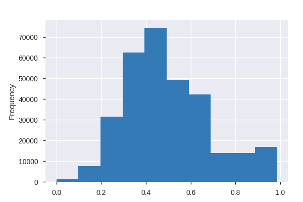

**Common Values**

| Value | Count | Frequency (%) |  |
| --- | --- | --- | --- |
| 0.475784 | 9744 | 3.1% |  |
| 0.503312 | 5421 | 1.7% |  |
| 0.325401 | 5001 | 1.6% |  |
| 0.54667 | 4930 | 1.6% |  |
| 0.484469 | 4473 | 1.4% |  |
| 0.330514 | 4469 | 1.4% |  |
| 0.480125 | 4252 | 1.4% |  |
| 0.894333 | 3783 | 1.2% |  |
| 0.465671 | 3490 | 1.1% |  |
| 0.629339 | 3415 | 1.1% |  |
| Other values (646) | 264886 | 84.4% |  |

**Extreme Values**

Minimum 5 values

| Value | Count | Frequency (%) |  |
| --- | --- | --- | --- |
| 1.6e-05 | 364 | 0.1% |  |
| 0.007274 | 55 | 0.0% |  |
| 0.016235 | 3 | 0.0% |  |
| 0.048643 | 23 | 0.0% |  |
| 0.057987 | 266 | 0.1% |  |

Maximum 5 values

| Value | Count | Frequency (%) |  |
| --- | --- | --- | --- |
| 0.980582 | 4 | 0.0% |  |
| 0.980802 | 60 | 0.0% |  |
| 0.981552 | 20 | 0.0% |  |
| 0.984452 | 11 | 0.0% |  |
| 0.984975 | 3 | 0.0% |  |

cont10  
Numeric

| Distinct count | 177 |
| --- | --- |
| Unique (%) | 0.1% |
| Missing (%) | 0.0% |
| Missing (n) | 0 |
| Infinite (%) | 0.0% |
| Infinite (n) | 0 |

| Mean | 0.4984 |
| --- | --- |
| Minimum | 0 |
| Maximum | 0.99498 |
| Zeros (%) | 0.1% |

Toggle details

**Statistics**

Quantile statistics

| Minimum | 0 |
| --- | --- |
| 5-th percentile | 0.21983 |
| Q1 | 0.36458 |
| Median | 0.46119 |
| Q3 | 0.61984 |
| 95-th percentile | 0.81923 |
| Maximum | 0.99498 |
| Range | 0.99498 |
| Interquartile range | 0.25526 |

Descriptive statistics

| Standard deviation | 0.18591 |
| --- | --- |
| Coef of variation | 0.373 |
| Kurtosis | -0.85586 |
| Mean | 0.4984 |
| MAD | 0.15349 |
| Skewness | 0.35212 |
| Sum | 156430 |
| Variance | 0.034561 |
| Memory size | 2.4 MiB |

**Histogram**

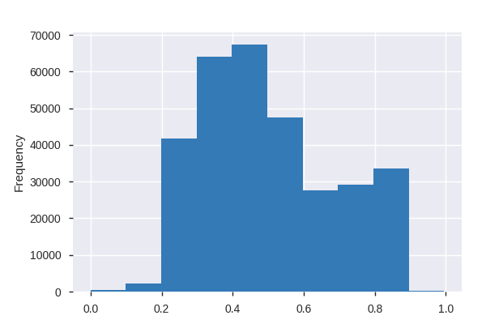

**Common Values**

| Value | Count | Frequency (%) |  |
| --- | --- | --- | --- |
| 0.45017 | 11897 | 3.8% |  |
| 0.43919 | 11888 | 3.8% |  |
| 0.8351 | 9758 | 3.1% |  |
| 0.47779 | 8131 | 2.6% |  |
| 0.39599 | 8084 | 2.6% |  |
| 0.50556 | 7947 | 2.5% |  |
| 0.2123 | 7292 | 2.3% |  |
| 0.44467 | 7240 | 2.3% |  |
| 0.36458 | 6760 | 2.2% |  |
| 0.37493 | 6549 | 2.1% |  |
| Other values (167) | 228318 | 72.7% |  |

**Extreme Values**

Minimum 5 values

| Value | Count | Frequency (%) |  |
| --- | --- | --- | --- |
| 0.0 | 366 | 0.1% |  |
| 0.06232 | 1 | 0.0% |  |
| 0.07664 | 55 | 0.0% |  |
| 0.09777 | 7 | 0.0% |  |
| 0.09975 | 1 | 0.0% |  |

Maximum 5 values

| Value | Count | Frequency (%) |  |
| --- | --- | --- | --- |
| 0.99048 | 72 | 0.0% |  |
| 0.99451 | 58 | 0.0% |  |
| 0.99463 | 82 | 0.0% |  |
| 0.99475 | 12 | 0.0% |  |
| 0.99498 | 6 | 0.0% |  |

cont11  
Numeric

| Distinct count | 337 |
| --- | --- |
| Unique (%) | 0.1% |
| Missing (%) | 0.0% |
| Missing (n) | 0 |
| Infinite (%) | 0.0% |
| Infinite (n) | 0 |

| Mean | 0.49385 |
| --- | --- |
| Minimum | 0.035321 |
| Maximum | 0.99874 |
| Zeros (%) | 0.0% |

Toggle details

**Statistics**

Quantile statistics

| Minimum | 0.035321 |
| --- | --- |
| 5-th percentile | 0.19965 |
| Q1 | 0.31096 |
| Median | 0.4572 |
| Q3 | 0.67892 |
| 95-th percentile | 0.83727 |
| Maximum | 0.99874 |
| Range | 0.96342 |
| Interquartile range | 0.36796 |

Descriptive statistics

| Standard deviation | 0.21 |
| --- | --- |
| Coef of variation | 0.42523 |
| Kurtosis | -1.0498 |
| Mean | 0.49385 |
| MAD | 0.18184 |
| Skewness | 0.28114 |
| Sum | 155000 |
| Variance | 0.044101 |
| Memory size | 2.4 MiB |

**Histogram**

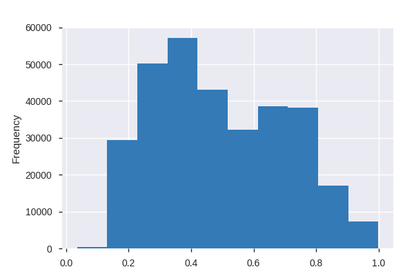

**Common Values**

| Value | Count | Frequency (%) |  |
| --- | --- | --- | --- |
| 0.341813 | 12023 | 3.8% |  |
| 0.453334 | 10885 | 3.5% |  |
| 0.4922 | 10100 | 3.2% |  |
| 0.24541 | 9821 | 3.1% |  |
| 0.644013 | 7277 | 2.3% |  |
| 0.415029 | 6931 | 2.2% |  |
| 0.307628 | 6782 | 2.2% |  |
| 0.6075 | 6588 | 2.1% |  |
| 0.569745 | 6525 | 2.1% |  |
| 0.797841 | 6305 | 2.0% |  |
| Other values (327) | 230627 | 73.5% |  |

**Extreme Values**

Minimum 5 values

| Value | Count | Frequency (%) |  |
| --- | --- | --- | --- |
| 0.035321 | 111 | 0.0% |  |
| 0.038077 | 1 | 0.0% |  |
| 0.068798 | 1 | 0.0% |  |
| 0.07949 | 3 | 0.0% |  |
| 0.085388 | 1 | 0.0% |  |

Maximum 5 values

| Value | Count | Frequency (%) |  |
| --- | --- | --- | --- |
| 0.997796 | 8 | 0.0% |  |
| 0.99783 | 3 | 0.0% |  |
| 0.998309 | 1 | 0.0% |  |
| 0.998702 | 1 | 0.0% |  |
| 0.998742 | 2 | 0.0% |  |

`cont12`  
Highly correlated

*This variable is highly correlated with `cont11` and should be ignored for analysis*

| Correlation | 0.99439 |
| --- | --- |

cont13  
Numeric

| Distinct count | 361 |
| --- | --- |
| Unique (%) | 0.1% |
| Missing (%) | 0.0% |
| Missing (n) | 0 |
| Infinite (%) | 0.0% |
| Infinite (n) | 0 |

| Mean | 0.49392 |
| --- | --- |
| Minimum | 0.000228 |
| Maximum | 0.98849 |
| Zeros (%) | 0.0% |

Toggle details

**Statistics**

Quantile statistics

| Minimum | 0.000228 |
| --- | --- |
| 5-th percentile | 0.25099 |
| Q1 | 0.31576 |
| Median | 0.36355 |
| Q3 | 0.68997 |
| 95-th percentile | 0.85153 |
| Maximum | 0.98849 |
| Range | 0.98827 |
| Interquartile range | 0.37422 |

Descriptive statistics

| Standard deviation | 0.21291 |
| --- | --- |
| Coef of variation | 0.43107 |
| Kurtosis | -1.3526 |
| Mean | 0.49392 |
| MAD | 0.19723 |
| Skewness | 0.37614 |
| Sum | 155020 |
| Variance | 0.045331 |
| Memory size | 2.4 MiB |

**Histogram**

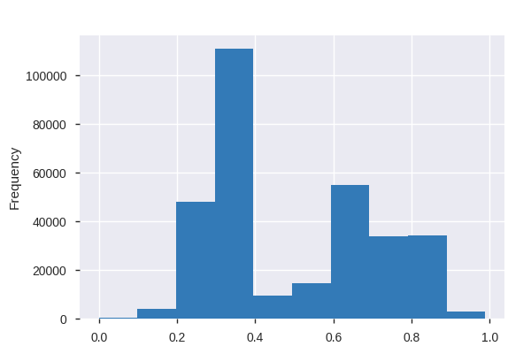

**Common Values**

| Value | Count | Frequency (%) |  |
| --- | --- | --- | --- |
| 0.339244 | 14784 | 4.7% |  |
| 0.689974 | 8660 | 2.8% |  |
| 0.30435 | 7928 | 2.5% |  |
| 0.315758 | 7569 | 2.4% |  |
| 0.333292 | 7454 | 2.4% |  |
| 0.345247 | 6363 | 2.0% |  |
| 0.318646 | 6323 | 2.0% |  |
| 0.298734 | 5943 | 1.9% |  |
| 0.611431 | 5720 | 1.8% |  |
| 0.363547 | 5105 | 1.6% |  |
| Other values (351) | 238015 | 75.8% |  |

**Extreme Values**

Minimum 5 values

| Value | Count | Frequency (%) |  |
| --- | --- | --- | --- |
| 0.000228 | 365 | 0.1% |  |
| 0.070001 | 1 | 0.0% |  |
| 0.073554 | 3 | 0.0% |  |
| 0.074468 | 5 | 0.0% |  |
| 0.077272 | 1 | 0.0% |  |

Maximum 5 values

| Value | Count | Frequency (%) |  |
| --- | --- | --- | --- |
| 0.948826 | 4 | 0.0% |  |
| 0.982248 | 4 | 0.0% |  |
| 0.982479 | 6 | 0.0% |  |
| 0.985419 | 2 | 0.0% |  |
| 0.988494 | 13 | 0.0% |  |

cont14  
Numeric

| Distinct count | 21372 |
| --- | --- |
| Unique (%) | 6.8% |
| Missing (%) | 0.0% |
| Missing (n) | 0 |
| Infinite (%) | 0.0% |
| Infinite (n) | 0 |

| Mean | 0.49566 |
| --- | --- |
| Minimum | 0.17857 |
| Maximum | 0.84485 |
| Zeros (%) | 0.0% |

Toggle details

**Statistics**

Quantile statistics

| Minimum | 0.17857 |
| --- | --- |
| 5-th percentile | 0.21466 |
| Q1 | 0.29466 |
| Median | 0.40702 |
| Q3 | 0.72471 |
| 95-th percentile | 0.82325 |
| Maximum | 0.84485 |
| Range | 0.66628 |
| Interquartile range | 0.43005 |

Descriptive statistics

| Standard deviation | 0.22254 |
| --- | --- |
| Coef of variation | 0.44897 |
| Kurtosis | -1.5297 |
| Mean | 0.49566 |
| MAD | 0.20438 |
| Skewness | 0.25067 |
| Sum | 155570 |
| Variance | 0.049523 |
| Memory size | 2.4 MiB |

**Histogram**

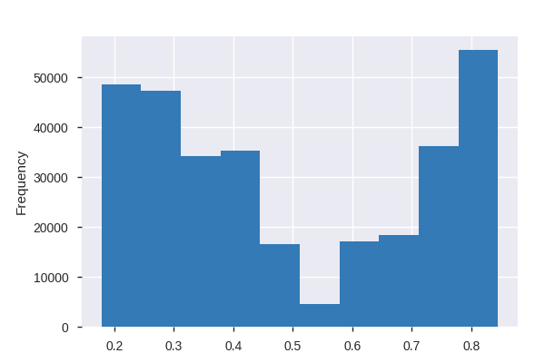

**Common Values**

| Value | Count | Frequency (%) |  |
| --- | --- | --- | --- |
| 0.297706 | 286 | 0.1% |  |
| 0.740079 | 272 | 0.1% |  |
| 0.22944 | 268 | 0.1% |  |
| 0.297137 | 232 | 0.1% |  |
| 0.229429 | 231 | 0.1% |  |
| 0.283811 | 222 | 0.1% |  |
| 0.295676 | 215 | 0.1% |  |
| 0.233142 | 212 | 0.1% |  |
| 0.237754 | 206 | 0.1% |  |
| 0.708475 | 206 | 0.1% |  |
| Other values (21362) | 311514 | 99.3% |  |

**Extreme Values**

Minimum 5 values

| Value | Count | Frequency (%) |  |
| --- | --- | --- | --- |
| 0.178568 | 1 | 0.0% |  |
| 0.179722 | 1 | 0.0% |  |
| 0.180268 | 1 | 0.0% |  |
| 0.180421 | 1 | 0.0% |  |
| 0.180426 | 1 | 0.0% |  |

Maximum 5 values

| Value | Count | Frequency (%) |  |
| --- | --- | --- | --- |
| 0.844729 | 21 | 0.0% |  |
| 0.844814 | 3 | 0.0% |  |
| 0.844831 | 1 | 0.0% |  |
| 0.844844 | 2 | 0.0% |  |
| 0.844848 | 1 | 0.0% |  |

cont2  
Numeric

| Distinct count | 33 |
| --- | --- |
| Unique (%) | 0.0% |
| Missing (%) | 0.0% |
| Missing (n) | 0 |
| Infinite (%) | 0.0% |
| Infinite (n) | 0 |

| Mean | 0.50709 |
| --- | --- |
| Minimum | 0.001149 |
| Maximum | 0.86265 |
| Zeros (%) | 0.0% |

Toggle details

**Statistics**

Quantile statistics

| Minimum | 0.001149 |
| --- | --- |
| 5-th percentile | 0.15999 |
| Q1 | 0.35832 |
| Median | 0.55578 |
| Q3 | 0.68176 |
| 95-th percentile | 0.78578 |
| Maximum | 0.86265 |
| Range | 0.86151 |
| Interquartile range | 0.32344 |

Descriptive statistics

| Standard deviation | 0.20706 |
| --- | --- |
| Coef of variation | 0.40832 |
| Kurtosis | -0.89246 |
| Mean | 0.50709 |
| MAD | 0.17524 |
| Skewness | -0.31115 |
| Sum | 159160 |
| Variance | 0.042872 |
| Memory size | 2.4 MiB |

**Histogram**

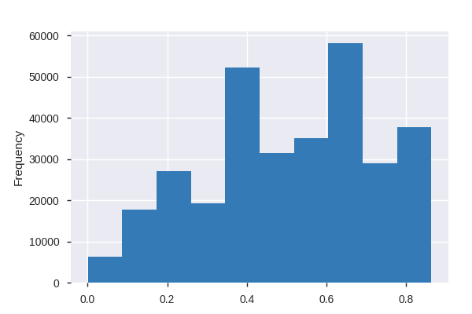

**Common Values**

| Value | Count | Frequency (%) |  |
| --- | --- | --- | --- |
| 0.555782 | 35063 | 11.2% |  |
| 0.620805 | 33670 | 10.7% |  |
| 0.488789 | 31477 | 10.0% |  |
| 0.737068 | 28951 | 9.2% |  |
| 0.422197 | 28177 | 9.0% |  |
| 0.785784 | 25888 | 8.2% |  |
| 0.681761 | 24430 | 7.8% |  |
| 0.358319 | 23970 | 7.6% |  |
| 0.299102 | 19306 | 6.2% |  |
| 0.245921 | 15626 | 5.0% |  |
| Other values (23) | 47306 | 15.1% |  |

**Extreme Values**

Minimum 5 values

| Value | Count | Frequency (%) |  |
| --- | --- | --- | --- |
| 0.001149 | 6 | 0.0% |  |
| 0.001503 | 7 | 0.0% |  |
| 0.001966 | 8 | 0.0% |  |
| 0.002571 | 14 | 0.0% |  |
| 0.003362 | 25 | 0.0% |  |

Maximum 5 values

| Value | Count | Frequency (%) |  |
| --- | --- | --- | --- |
| 0.681761 | 24430 | 7.8% |  |
| 0.737068 | 28951 | 9.2% |  |
| 0.785784 | 25888 | 8.2% |  |
| 0.827585 | 11606 | 3.7% |  |
| 0.862654 | 294 | 0.1% |  |

cont3  
Numeric

| Distinct count | 77 |
| --- | --- |
| Unique (%) | 0.0% |
| Missing (%) | 0.0% |
| Missing (n) | 0 |
| Infinite (%) | 0.0% |
| Infinite (n) | 0 |

| Mean | 0.49865 |
| --- | --- |
| Minimum | 0.002634 |
| Maximum | 0.94425 |
| Zeros (%) | 0.0% |

Toggle details

**Statistics**

Quantile statistics

| Minimum | 0.002634 |
| --- | --- |
| 5-th percentile | 0.17459 |
| Q1 | 0.33696 |
| Median | 0.52799 |
| Q3 | 0.63422 |
| 95-th percentile | 0.81975 |
| Maximum | 0.94425 |
| Range | 0.94162 |
| Interquartile range | 0.29726 |

Descriptive statistics

| Standard deviation | 0.20196 |
| --- | --- |
| Coef of variation | 0.40501 |
| Kurtosis | -0.605 |
| Mean | 0.49865 |
| MAD | 0.16397 |
| Skewness | -0.0070235 |
| Sum | 156510 |
| Variance | 0.040788 |
| Memory size | 2.4 MiB |

**Histogram**

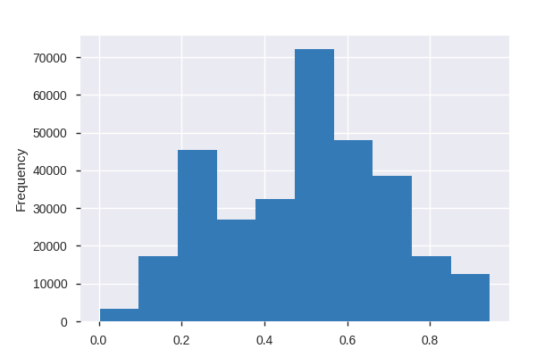

**Common Values**

| Value | Count | Frequency (%) |  |
| --- | --- | --- | --- |
| 0.54977 | 27589 | 8.8% |  |
| 0.506105 | 15405 | 4.9% |  |
| 0.484196 | 15385 | 4.9% |  |
| 0.527991 | 13750 | 4.4% |  |
| 0.336963 | 12655 | 4.0% |  |
| 0.61366 | 12366 | 3.9% |  |
| 0.692825 | 11802 | 3.8% |  |
| 0.440642 | 11466 | 3.7% |  |
| 0.592681 | 10859 | 3.5% |  |
| 0.57136 | 10146 | 3.2% |  |
| Other values (67) | 172441 | 54.9% |  |

**Extreme Values**

Minimum 5 values

| Value | Count | Frequency (%) |  |
| --- | --- | --- | --- |
| 0.002634 | 135 | 0.0% |  |
| 0.01945 | 2 | 0.0% |  |
| 0.025153 | 4 | 0.0% |  |
| 0.027395 | 7 | 0.0% |  |
| 0.02983 | 10 | 0.0% |  |

Maximum 5 values

| Value | Count | Frequency (%) |  |
| --- | --- | --- | --- |
| 0.922649 | 107 | 0.0% |  |
| 0.928678 | 58 | 0.0% |  |
| 0.93427 | 5 | 0.0% |  |
| 0.939453 | 803 | 0.3% |  |
| 0.944251 | 7751 | 2.5% |  |

cont4  
Numeric

| Distinct count | 113 |
| --- | --- |
| Unique (%) | 0.0% |
| Missing (%) | 0.0% |
| Missing (n) | 0 |
| Infinite (%) | 0.0% |
| Infinite (n) | 0 |

| Mean | 0.49202 |
| --- | --- |
| Minimum | 0.17692 |
| Maximum | 0.95605 |
| Zeros (%) | 0.0% |

Toggle details

**Statistics**

Quantile statistics

| Minimum | 0.17692 |
| --- | --- |
| 5-th percentile | 0.20865 |
| Q1 | 0.32735 |
| Median | 0.45289 |
| Q3 | 0.65207 |
| 95-th percentile | 0.86459 |
| Maximum | 0.95605 |
| Range | 0.77912 |
| Interquartile range | 0.32472 |

Descriptive statistics

| Standard deviation | 0.2111 |
| --- | --- |
| Coef of variation | 0.42905 |
| Kurtosis | -0.96114 |
| Mean | 0.49202 |
| MAD | 0.17873 |
| Skewness | 0.41756 |
| Sum | 154430 |
| Variance | 0.044564 |
| Memory size | 2.4 MiB |

**Histogram**

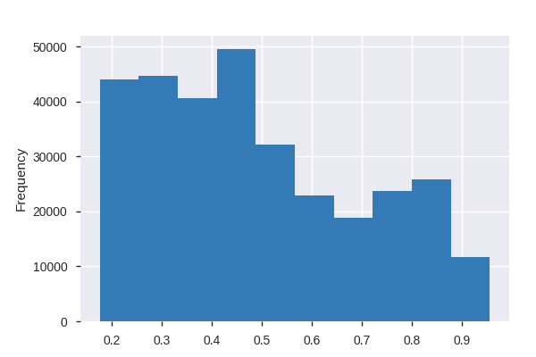

**Common Values**

| Value | Count | Frequency (%) |  |
| --- | --- | --- | --- |
| 0.373816 | 16360 | 5.2% |  |
| 0.473202 | 13150 | 4.2% |  |
| 0.327354 | 11369 | 3.6% |  |
| 0.309621 | 9789 | 3.1% |  |
| 0.452887 | 8881 | 2.8% |  |
| 0.432728 | 8585 | 2.7% |  |
| 0.412789 | 7884 | 2.5% |  |
| 0.534409 | 7717 | 2.5% |  |
| 0.208655 | 7689 | 2.4% |  |
| 0.62377 | 7171 | 2.3% |  |
| Other values (103) | 215269 | 68.6% |  |

**Extreme Values**

Minimum 5 values

| Value | Count | Frequency (%) |  |
| --- | --- | --- | --- |
| 0.176921 | 1850 | 0.6% |  |
| 0.18295 | 3211 | 1.0% |  |
| 0.189137 | 5127 | 1.6% |  |
| 0.195483 | 3366 | 1.1% |  |
| 0.201989 | 804 | 0.3% |  |

Maximum 5 values

| Value | Count | Frequency (%) |  |
| --- | --- | --- | --- |
| 0.948643 | 1058 | 0.3% |  |
| 0.950598 | 35 | 0.0% |  |
| 0.952482 | 185 | 0.1% |  |
| 0.954297 | 2 | 0.0% |  |
| 0.956046 | 1 | 0.0% |  |

cont5  
Numeric

| Distinct count | 144 |
| --- | --- |
| Unique (%) | 0.0% |
| Missing (%) | 0.0% |
| Missing (n) | 0 |
| Infinite (%) | 0.0% |
| Infinite (n) | 0 |

| Mean | 0.48751 |
| --- | --- |
| Minimum | 0.28114 |
| Maximum | 0.98367 |
| Zeros (%) | 0.0% |

Toggle details

**Statistics**

Quantile statistics

| Minimum | 0.28114 |
| --- | --- |
| 5-th percentile | 0.28114 |
| Q1 | 0.28114 |
| Median | 0.42227 |
| Q3 | 0.64331 |
| 95-th percentile | 0.88227 |
| Maximum | 0.98367 |
| Range | 0.70253 |
| Interquartile range | 0.36217 |

Descriptive statistics

| Standard deviation | 0.20906 |
| --- | --- |
| Coef of variation | 0.42884 |
| Kurtosis | -0.88157 |
| Mean | 0.48751 |
| MAD | 0.18012 |
| Skewness | 0.67961 |
| Sum | 153010 |
| Variance | 0.043707 |
| Memory size | 2.4 MiB |

**Histogram**

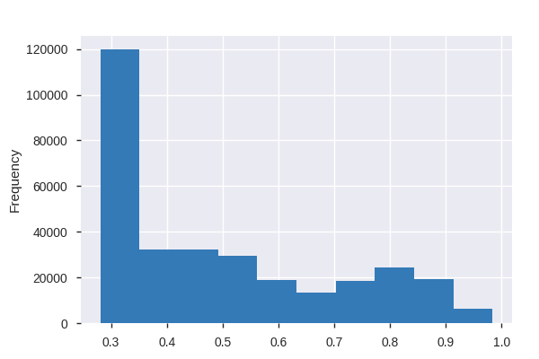

**Common Values**

| Value | Count | Frequency (%) |  |
| --- | --- | --- | --- |
| 0.281143 | 86705 | 27.6% |  |
| 0.422268 | 15059 | 4.8% |  |
| 0.302678 | 13067 | 4.2% |  |
| 0.372405 | 7859 | 2.5% |  |
| 0.594196 | 6221 | 2.0% |  |
| 0.78323 | 5825 | 1.9% |  |
| 0.551723 | 5730 | 1.8% |  |
| 0.534484 | 5359 | 1.7% |  |
| 0.388783 | 5213 | 1.7% |  |
| 0.491114 | 5174 | 1.6% |  |
| Other values (134) | 157652 | 50.2% |  |

**Extreme Values**

Minimum 5 values

| Value | Count | Frequency (%) |  |
| --- | --- | --- | --- |
| 0.281143 | 86705 | 27.6% |  |
| 0.288217 | 3605 | 1.1% |  |
| 0.295397 | 4454 | 1.4% |  |
| 0.302678 | 13067 | 4.2% |  |
| 0.310061 | 2605 | 0.8% |  |

Maximum 5 values

| Value | Count | Frequency (%) |  |
| --- | --- | --- | --- |
| 0.981286 | 67 | 0.0% |  |
| 0.981914 | 4 | 0.0% |  |
| 0.98252 | 90 | 0.0% |  |
| 0.983107 | 1 | 0.0% |  |
| 0.983674 | 2 | 0.0% |  |

cont6  
Numeric

| Distinct count | 2687 |
| --- | --- |
| Unique (%) | 0.9% |
| Missing (%) | 0.0% |
| Missing (n) | 0 |
| Infinite (%) | 0.0% |
| Infinite (n) | 0 |

| Mean | 0.49144 |
| --- | --- |
| Minimum | 0.012683 |
| Maximum | 0.99716 |
| Zeros (%) | 0.0% |

Toggle details

**Statistics**

Quantile statistics

| Minimum | 0.012683 |
| --- | --- |
| 5-th percentile | 0.20685 |
| Q1 | 0.33611 |
| Median | 0.44094 |
| Q3 | 0.65582 |
| 95-th percentile | 0.8677 |
| Maximum | 0.99716 |
| Range | 0.98448 |
| Interquartile range | 0.31971 |

Descriptive statistics

| Standard deviation | 0.20539 |
| --- | --- |
| Coef of variation | 0.41794 |
| Kurtosis | -0.76776 |
| Mean | 0.49144 |
| MAD | 0.17367 |
| Skewness | 0.45842 |
| Sum | 154250 |
| Variance | 0.042187 |
| Memory size | 2.4 MiB |

**Histogram**

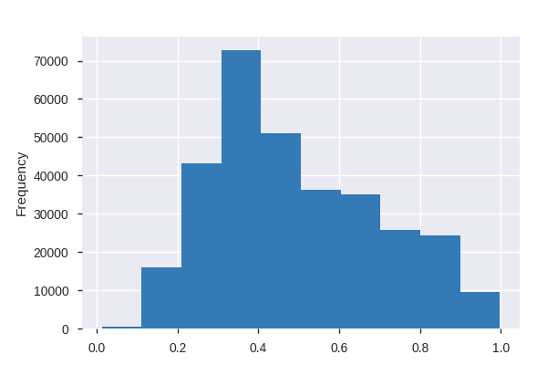

**Common Values**

| Value | Count | Frequency (%) |  |
| --- | --- | --- | --- |
| 0.3735 | 5012 | 1.6% |  |
| 0.364464 | 4211 | 1.3% |  |
| 0.240069 | 3456 | 1.1% |  |
| 0.201125 | 2594 | 0.8% |  |
| 0.317735 | 2499 | 0.8% |  |
| 0.220686 | 1865 | 0.6% |  |
| 0.379574 | 1810 | 0.6% |  |
| 0.252511 | 1775 | 0.6% |  |
| 0.220282 | 1749 | 0.6% |  |
| 0.336105 | 1688 | 0.5% |  |
| Other values (2677) | 287205 | 91.5% |  |

**Extreme Values**

Minimum 5 values

| Value | Count | Frequency (%) |  |
| --- | --- | --- | --- |
| 0.012683 | 351 | 0.1% |  |
| 0.08608 | 1 | 0.0% |  |
| 0.096818 | 1 | 0.0% |  |
| 0.09723 | 47 | 0.0% |  |
| 0.101117 | 1 | 0.0% |  |

Maximum 5 values

| Value | Count | Frequency (%) |  |
| --- | --- | --- | --- |
| 0.98896 | 16 | 0.0% |  |
| 0.989024 | 11 | 0.0% |  |
| 0.99548 | 1 | 0.0% |  |
| 0.996786 | 3 | 0.0% |  |
| 0.997162 | 10 | 0.0% |  |

cont7  
Numeric

| Distinct count | 6063 |
| --- | --- |
| Unique (%) | 1.9% |
| Missing (%) | 0.0% |
| Missing (n) | 0 |
| Infinite (%) | 0.0% |
| Infinite (n) | 0 |

| Mean | 0.48536 |
| --- | --- |
| Minimum | 0.069503 |
| Maximum | 1 |
| Zeros (%) | 0.0% |

Toggle details

**Statistics**

Quantile statistics

| Minimum | 0.069503 |
| --- | --- |
| 5-th percentile | 0.26234 |
| Q1 | 0.3513 |
| Median | 0.43865 |
| Q3 | 0.59116 |
| 95-th percentile | 0.84947 |
| Maximum | 1 |
| Range | 0.9305 |
| Interquartile range | 0.23987 |

Descriptive statistics

| Standard deviation | 0.17853 |
| --- | --- |
| Coef of variation | 0.36783 |
| Kurtosis | 0.049055 |
| Mean | 0.48536 |
| MAD | 0.14512 |
| Skewness | 0.82589 |
| Sum | 152340 |
| Variance | 0.031873 |
| Memory size | 2.4 MiB |

**Histogram**

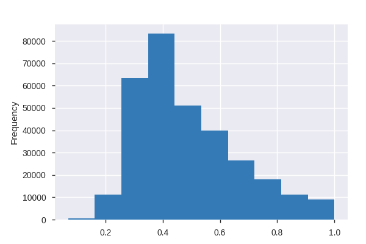

**Common Values**

| Value | Count | Frequency (%) |  |
| --- | --- | --- | --- |
| 0.347485 | 1950 | 0.6% |  |
| 0.350175 | 1775 | 0.6% |  |
| 0.381883 | 1733 | 0.6% |  |
| 0.283691 | 1602 | 0.5% |  |
| 0.362399 | 1334 | 0.4% |  |
| 0.39101 | 1294 | 0.4% |  |
| 0.401162 | 1265 | 0.4% |  |
| 0.359439 | 1234 | 0.4% |  |
| 0.279895 | 1122 | 0.4% |  |
| 0.409251 | 1090 | 0.3% |  |
| Other values (6053) | 299465 | 95.4% |  |

**Extreme Values**

Minimum 5 values

| Value | Count | Frequency (%) |  |
| --- | --- | --- | --- |
| 0.069503 | 493 | 0.2% |  |
| 0.123055 | 1 | 0.0% |  |
| 0.137667 | 1 | 0.0% |  |
| 0.138701 | 1 | 0.0% |  |
| 0.13928 | 1 | 0.0% |  |

Maximum 5 values

| Value | Count | Frequency (%) |  |
| --- | --- | --- | --- |
| 0.999996 | 3 | 0.0% |  |
| 0.999997 | 3 | 0.0% |  |
| 0.999998 | 1 | 0.0% |  |
| 0.999999 | 10 | 0.0% |  |
| 1.0 | 47 | 0.0% |  |

cont8  
Numeric

| Distinct count | 203 |
| --- | --- |
| Unique (%) | 0.1% |
| Missing (%) | 0.0% |
| Missing (n) | 0 |
| Infinite (%) | 0.0% |
| Infinite (n) | 0 |

| Mean | 0.48682 |
| --- | --- |
| Minimum | 0.23688 |
| Maximum | 0.9828 |
| Zeros (%) | 0.0% |

Toggle details

**Statistics**

Quantile statistics

| Minimum | 0.23688 |
| --- | --- |
| 5-th percentile | 0.24564 |
| Q1 | 0.31796 |
| Median | 0.44106 |
| Q3 | 0.62358 |
| 95-th percentile | 0.88693 |
| Maximum | 0.9828 |
| Range | 0.74592 |
| Interquartile range | 0.30562 |

Descriptive statistics

| Standard deviation | 0.19944 |
| --- | --- |
| Coef of variation | 0.40968 |
| Kurtosis | -0.54958 |
| Mean | 0.48682 |
| MAD | 0.16925 |
| Skewness | 0.67324 |
| Sum | 152800 |
| Variance | 0.039777 |
| Memory size | 2.4 MiB |

**Histogram**

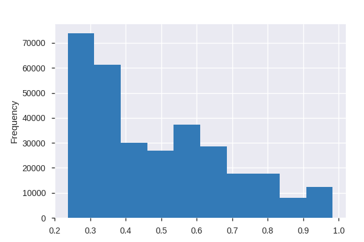

**Common Values**

| Value | Count | Frequency (%) |  |
| --- | --- | --- | --- |
| 0.26847 | 18673 | 5.9% |  |
| 0.36083 | 15486 | 4.9% |  |
| 0.24564 | 13687 | 4.4% |  |
| 0.29758 | 7586 | 2.4% |  |
| 0.27797 | 7521 | 2.4% |  |
| 0.58354 | 6963 | 2.2% |  |
| 0.33906 | 6601 | 2.1% |  |
| 0.34987 | 5777 | 1.8% |  |
| 0.31796 | 5135 | 1.6% |  |
| 0.3128 | 4590 | 1.5% |  |
| Other values (193) | 221845 | 70.7% |  |

**Extreme Values**

Minimum 5 values

| Value | Count | Frequency (%) |  |
| --- | --- | --- | --- |
| 0.23688 | 1690 | 0.5% |  |
| 0.24123 | 2604 | 0.8% |  |
| 0.24564 | 13687 | 4.4% |  |
| 0.2501 | 1015 | 0.3% |  |
| 0.25461 | 3308 | 1.1% |  |

Maximum 5 values

| Value | Count | Frequency (%) |  |
| --- | --- | --- | --- |
| 0.97875 | 10 | 0.0% |  |
| 0.97925 | 44 | 0.0% |  |
| 0.97973 | 796 | 0.3% |  |
| 0.9802 | 470 | 0.1% |  |
| 0.9828 | 2 | 0.0% |  |

`cont9`  
Highly correlated

*This variable is highly correlated with `cont1` and should be ignored for analysis*

| Correlation | 0.93067 |
| --- | --- |

id  
Numeric

| Distinct count | 313864 |
| --- | --- |
| Unique (%) | 100.0% |
| Missing (%) | 0.0% |
| Missing (n) | 0 |
| Infinite (%) | 0.0% |
| Infinite (n) | 0 |

| Mean | 294110 |
| --- | --- |
| Minimum | 1 |
| Maximum | 587634 |
| Zeros (%) | 0.0% |

Toggle details

**Statistics**

Quantile statistics

| Minimum | 1 |
| --- | --- |
| 5-th percentile | 29560 |
| Q1 | 147260 |
| Median | 294430 |
| Q3 | 441180 |
| 95-th percentile | 558270 |
| Maximum | 587634 |
| Range | 587633 |
| Interquartile range | 293910 |

Descriptive statistics

| Standard deviation | 169640 |
| --- | --- |
| Coef of variation | 0.5768 |
| Kurtosis | -1.2015 |
| Mean | 294110 |
| MAD | 146960 |
| Skewness | -0.0024339 |
| Sum | 92310054810 |
| Variance | 28778000000 |
| Memory size | 2.4 MiB |

**Histogram**

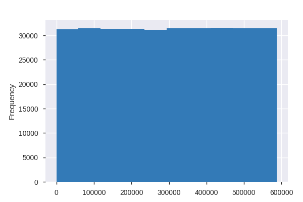

**Common Values**

| Value | Count | Frequency (%) |  |
| --- | --- | --- | --- |
| 2047 | 1 | 0.0% |  |
| 236070 | 1 | 0.0% |  |
| 135703 | 1 | 0.0% |  |
| 150044 | 1 | 0.0% |  |
| 147997 | 1 | 0.0% |  |
| 240160 | 1 | 0.0% |  |
| 244258 | 1 | 0.0% |  |
| 242211 | 1 | 0.0% |  |
| 229925 | 1 | 0.0% |  |
| 254505 | 1 | 0.0% |  |
| Other values (313854) | 313854 | 100.0% |  |

**Extreme Values**

Minimum 5 values

| Value | Count | Frequency (%) |  |
| --- | --- | --- | --- |
| 1 | 1 | 0.0% |  |
| 2 | 1 | 0.0% |  |
| 4 | 1 | 0.0% |  |
| 5 | 1 | 0.0% |  |
| 6 | 1 | 0.0% |  |

Maximum 5 values

| Value | Count | Frequency (%) |  |
| --- | --- | --- | --- |
| 587629 | 1 | 0.0% |  |
| 587630 | 1 | 0.0% |  |
| 587632 | 1 | 0.0% |  |
| 587633 | 1 | 0.0% |  |
| 587634 | 1 | 0.0% |  |

# Sample

| id | cat1 | cat2 | cat3 | cat4 | cat5 | cat6 | cat7 | cat8 | cat9 | cat10 | cat11 | cat12 | cat13 | cat14 | cat15 | cat16 | cat17 | cat18 | cat19 | cat20 | cat21 | cat22 | cat23 | cat24 | cat25 | cat26 | cat27 | cat28 | cat29 | … |
| --- | --- | --- | --- | --- | --- | --- | --- | --- | --- | --- | --- | --- | --- | --- | --- | --- | --- | --- | --- | --- | --- | --- | --- | --- | --- | --- | --- | --- | --- | --- |
| 1 | A | B | A | B | A | A | A | A | B | A | B | A | A | A | A | A | A | A | A | A | A | A | B | A | A | A | A | A | A | … |
| 2 | A | B | A | A | A | A | A | A | B | B | A | A | A | A | A | A | A | A | A | A | A | A | A | A | A | A | A | A | A | … |
| 5 | A | B | A | A | B | A | A | A | B | B | B | B | B | A | A | A | A | A | A | A | A | A | A | A | A | A | A | A | A | … |
| 10 | B | B | A | B | A | A | A | A | B | A | A | A | A | A | A | A | A | A | A | A | A | A | B | A | A | A | A | A | A | … |
| 11 | A | B | A | B | A | A | A | A | B | B | A | B | A | A | A | A | A | A | A | A | A | A | B | A | A | A | A | A | A | … |